[figure not shown]

# Face recognition

Task is to recognize faces

### Dataset

**Aligned Face Dataset from Pinterest**

This dataset contains 10.770 images for 100 people. All images are taken from 'Pinterest' and aligned using dlib library.

Overview In this problem, we use a pre-trained model trained on Face recognition to recognize similar faces. Here, we are particularly interested in recognizing whether two given faces are of the same person or not. Below are the steps involved in the project.

- Load the dataset and create the metadata.
- Check some samples of metadata.
- Load the pre-trained model and weights.
- Generate Embedding vectors for each face in the dataset.
- Build distance metrics for identifying the distance between two given images.
- Use PCA for dimensionality reduction.
- Build an SVM classifier to map each image to its right person.
- Predict using the SVM model.

```python
import numpy as np
import os
import cv2
from google.colab.patches import cv2_imshow
import tensorflow
tensorflow.__version__
```

```
'2.3.0'
```

```python
from tensorflow.keras.models import Model
from tqdm import tqdm
import matplotlib.pyplot as plt
from sklearn.preprocessing import LabelEncoder
from sklearn.preprocessing import StandardScaler
from sklearn.decomposition import PCA
from sklearn.svm import SVC
from sklearn.model_selection import GridSearchCV
from sklearn.metrics import f1_score, accuracy_score
```

#### Mount Google drive using google colab

```python
from google.colab import drive
drive.mount('/content/gdrive')
```

```
Go to this URL in a browser: https://accounts.google.com/o/oauth2/auth?client_id=947318989803-6bn6qk8qdgf4n4g3pfee6491hc0brc4i.apps.googleusercontent.com&redirect_uri=urn%3aietf%3awg%3aoauth%3a2.0%3aoob&scope=email%20https%3a%2f%2fwww.googleapis.com%2fauth%2fdocs.test%20https%3a%2f%2fwww.googleapis.…

Enter your authorization code:
··········
```

#### Change current working directory to project folder

```python
os.chdir('/content/gdrive/My Drive/AIML_Colab/Datasets/Face Recognition/')
```

```python
pwd
```

```
'/content/gdrive/My Drive/AIML_Colab/Datasets/Face Recognition'
```

### Extract the zip file

```python
from zipfile import ZipFile

with ZipFile('Aligned Face Dataset from Pinterest.zip','r') as z:
  z.extractall()
```

```python
ls
```

```
'Aligned Face Dataset from Pinterest.zip'   pins/   PINS/   vgg_face_weights.h5
```

```python
os.listdir('PINS')
```

```
['pins_Aaron Paul',
 'pins_Alvaro Morte',
 'pins_Amanda Crew',
 'pins_Amaury Nolasco',
 'pins_Anna Gunn',
 'pins_Benedict Cumberbatch',
 'pins_Betsy Brandt',
 'pins_Brenton Thwaites',
 'pins_Brit Marling',
 'pins_Bryan Cranston',
 'pins_Caity Lotz',
 'pins_Cameron Monaghan',
 'pins_Chance Perdomo',
 'pins_Chris Evans',
 'pins_Chris Pratt',
 'pins_Cobie Smulders',
 'pins_Danielle Panabaker',
 'pins_Dave Franco',
 'pins_Dominic Purcell',
 'pins_Dwayne Johnson',
 'pins_Emilia Clarke',
 'pins_Emily Bett Rickards',
 'pins_Emma Stone',
 'pins_Gwyneth Paltrow',
 'pins_Henry Cavil',
 'pins_Jason Momoa',
 'pins_Jeremy Renner',
 'pins_Jesse Eisenberg',
 'pins_Jim Parsons',
 'pins_Jon Bernthal',
 'pins_Josh Radnor',
 'pins_Kit Harington',
 'pins_Krysten Ritter',
 'pins_Kumail Nanjiani',
 'pins_Maisie Williams',
 'pins_Mark Ruffalo',
 'pins_Martin Starr',
 'pins_Melissa benoit',
 'pins_Mike Colter',
 'pins_Morena Baccarin',
```

[output cut: 45 more lines]

```
 'pins_lindsey morgan face',
 'pins_margot robbie face',
 'pins_maria pedraza',
 'pins_mark zuckerberg',
 'pins_miguel herran',
 'pins_millie bobby brown',
 'pins_rihanna',
 'pins_robert downey jr face',
 'pins_sean pertwee',
 'pins_selena gomez',
 'pins_shakira',
 'pins_tati gabrielle',
 'pins_taylor swift',
 'pins_tom holland face',
 'pins_zendaya']
```

### Function to load images

- Define a function to load the images from the extracted folder and map each image with person id

```python
class IdentityMetadata():
    def __init__(self, base, name, file):
        # print(base, name, file)
        # dataset base directory
        self.base = base
        # identity name
        self.name = name
        # image file name
        self.file = file

    def image_path(self):
        return os.path.join(self.base, self.name, self.file)

    def __repr__(self):
        return self.image_path()


def load_metadata(path):
    metadata = []
    for i in os.listdir(path):
        for f in os.listdir(os.path.join(path, i)):
            # Check file extension. Allow only jpg/jpeg' files.
            ext = os.path.splitext(f)[1]
            if ext == '.jpg' or ext == '.jpeg':
                metadata.append(IdentityMetadata(path, i, f))
    return np.array(metadata)

# metadata = load_metadata('images')
metadata = load_metadata('PINS')
```

### Define function to load image

- Define a function to load image from the metadata

```python
def load_image(path):
    img = cv2.imread(path, 1)
    # OpenCV loads images with color channels
    # in BGR order. So we need to reverse them
    return img[...,::-1]
```

```python
for i in range(len(metadata)):
  if str(metadata[i]) == 'PINS/pins_Caity Lotz/Caity Lotz28.jpg':
    print(i)
```

```
1028
```

#### Load a sample image

- Load one image using the function "load_image"

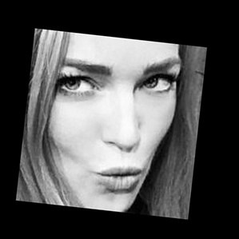

```python
cv2_imshow(load_image(metadata[1028].image_path()))
```

### VGG Face model

- Here we are giving you the predefined model for VGG face

```python
from tensorflow.keras.models import Sequential
from tensorflow.keras.layers import ZeroPadding2D, Convolution2D, MaxPooling2D, Dropout, Flatten, Activation

def vgg_face():
    model = Sequential()
    model.add(ZeroPadding2D((1,1),input_shape=(224,224, 3)))
    model.add(Convolution2D(64, (3, 3), activation='relu'))
    model.add(ZeroPadding2D((1,1)))
    model.add(Convolution2D(64, (3, 3), activation='relu'))
    model.add(MaxPooling2D((2,2), strides=(2,2)))

    model.add(ZeroPadding2D((1,1)))
    model.add(Convolution2D(128, (3, 3), activation='relu'))
    model.add(ZeroPadding2D((1,1)))
    model.add(Convolution2D(128, (3, 3), activation='relu'))
    model.add(MaxPooling2D((2,2), strides=(2,2)))

    model.add(ZeroPadding2D((1,1)))
    model.add(Convolution2D(256, (3, 3), activation='relu'))
    model.add(ZeroPadding2D((1,1)))
    model.add(Convolution2D(256, (3, 3), activation='relu'))
    model.add(ZeroPadding2D((1,1)))
    model.add(Convolution2D(256, (3, 3), activation='relu'))
    model.add(MaxPooling2D((2,2), strides=(2,2)))

    model.add(ZeroPadding2D((1,1)))
    model.add(Convolution2D(512, (3, 3), activation='relu'))
    model.add(ZeroPadding2D((1,1)))
    model.add(Convolution2D(512, (3, 3), activation='relu'))
    model.add(ZeroPadding2D((1,1)))
    model.add(Convolution2D(512, (3, 3), activation='relu'))
    model.add(MaxPooling2D((2,2), strides=(2,2)))

    model.add(ZeroPadding2D((1,1)))
    model.add(Convolution2D(512, (3, 3), activation='relu'))
    model.add(ZeroPadding2D((1,1)))
    model.add(Convolution2D(512, (3, 3), activation='relu'))
    model.add(ZeroPadding2D((1,1)))
    model.add(Convolution2D(512, (3, 3), activation='relu'))
    model.add(MaxPooling2D((2,2), strides=(2,2)))

    model.add(Convolution2D(4096, (7, 7), activation='relu'))
    model.add(Dropout(0.5))
    model.add(Convolution2D(4096, (1, 1), activation='relu'))
    model.add(Dropout(0.5))
    model.add(Convolution2D(2622, (1, 1)))
    model.add(Flatten())
    model.add(Activation('softmax'))
    return model
```

#### Load the model

- Load the model defined above
- Then load the given weight file named "vgg_face_weights.h5"

```python
model = vgg_face()
model.load_weights("vgg_face_weights.h5")
```

```python
model.summary()
```

```
Model: "sequential"
_________________________________________________________________
Layer (type)                 Output Shape              Param #
=================================================================
zero_padding2d (ZeroPadding2 (None, 226, 226, 3)       0
_________________________________________________________________
conv2d (Conv2D)              (None, 224, 224, 64)      1792
_________________________________________________________________
zero_padding2d_1 (ZeroPaddin (None, 226, 226, 64)      0
_________________________________________________________________
conv2d_1 (Conv2D)            (None, 224, 224, 64)      36928
_________________________________________________________________
max_pooling2d (MaxPooling2D) (None, 112, 112, 64)      0
_________________________________________________________________
zero_padding2d_2 (ZeroPaddin (None, 114, 114, 64)      0
_________________________________________________________________
conv2d_2 (Conv2D)            (None, 112, 112, 128)     73856
_________________________________________________________________
zero_padding2d_3 (ZeroPaddin (None, 114, 114, 128)     0
_________________________________________________________________
conv2d_3 (Conv2D)            (None, 112, 112, 128)     147584
_________________________________________________________________
max_pooling2d_1 (MaxPooling2 (None, 56, 56, 128)       0
_________________________________________________________________
zero_padding2d_4 (ZeroPaddin (None, 58, 58, 128)       0
_________________________________________________________________
conv2d_4 (Conv2D)            (None, 56, 56, 256)       295168
_________________________________________________________________
zero_padding2d_5 (ZeroPaddin (None, 58, 58, 256)       0
_________________________________________________________________
conv2d_5 (Conv2D)            (None, 56, 56, 256)       590080
_________________________________________________________________
zero_padding2d_6 (ZeroPaddin (None, 58, 58, 256)       0
_________________________________________________________________
conv2d_6 (Conv2D)            (None, 56, 56, 256)       590080
_________________________________________________________________
max_pooling2d_2 (MaxPooling2 (None, 28, 28, 256)       0
_________________________________________________________________
zero_padding2d_7 (ZeroPaddin (None, 30, 30, 256)       0
_________________________________________________________________
```

[output cut: 29 more lines]

```
_________________________________________________________________
conv2d_14 (Conv2D)           (None, 1, 1, 4096)        16781312
_________________________________________________________________
dropout_1 (Dropout)          (None, 1, 1, 4096)        0
_________________________________________________________________
conv2d_15 (Conv2D)           (None, 1, 1, 2622)        10742334
_________________________________________________________________
flatten (Flatten)            (None, 2622)              0
_________________________________________________________________
activation (Activation)      (None, 2622)              0
=================================================================
Total params: 145,002,878
Trainable params: 145,002,878
Non-trainable params: 0
_________________________________________________________________
```

```python
model.layers
```

```
[<tensorflow.python.keras.layers.convolutional.ZeroPadding2D at 0x7f1ab8a3f668>,
 <tensorflow.python.keras.layers.convolutional.Conv2D at 0x7f1ab8a3f358>,
 <tensorflow.python.keras.layers.convolutional.ZeroPadding2D at 0x7f1ab8a6c6a0>,
 <tensorflow.python.keras.layers.convolutional.Conv2D at 0x7f1ab8a6c780>,
 <tensorflow.python.keras.layers.pooling.MaxPooling2D at 0x7f1ab0227358>,
 <tensorflow.python.keras.layers.convolutional.ZeroPadding2D at 0x7f1ab0227ac8>,
 <tensorflow.python.keras.layers.convolutional.Conv2D at 0x7f1ab022f0f0>,
 <tensorflow.python.keras.layers.convolutional.ZeroPadding2D at 0x7f1ab022f588>,
 <tensorflow.python.keras.layers.convolutional.Conv2D at 0x7f1ab022f978>,
 <tensorflow.python.keras.layers.pooling.MaxPooling2D at 0x7f1ab01b8588>,
 <tensorflow.python.keras.layers.convolutional.ZeroPadding2D at 0x7f1ab01b8cf8>,
 <tensorflow.python.keras.layers.convolutional.Conv2D at 0x7f1ab01c3470>,
 <tensorflow.python.keras.layers.convolutional.ZeroPadding2D at 0x7f1ab01c37b8>,
 <tensorflow.python.keras.layers.convolutional.Conv2D at 0x7f1ab01c3c18>,
 <tensorflow.python.keras.layers.convolutional.ZeroPadding2D at 0x7f1ab01cc860>,
 <tensorflow.python.keras.layers.convolutional.Conv2D at 0x7f1ab01ccba8>,
 <tensorflow.python.keras.layers.pooling.MaxPooling2D at 0x7f1ab01d4748>,
 <tensorflow.python.keras.layers.convolutional.ZeroPadding2D at 0x7f1ab01d4eb8>,
 <tensorflow.python.keras.layers.convolutional.Conv2D at 0x7f1ab01df630>,
 <tensorflow.python.keras.layers.convolutional.ZeroPadding2D at 0x7f1ab01df978>,
 <tensorflow.python.keras.layers.convolutional.Conv2D at 0x7f1ab01dfdd8>,
 <tensorflow.python.keras.layers.convolutional.ZeroPadding2D at 0x7f1ab01e7a20>,
 <tensorflow.python.keras.layers.convolutional.Conv2D at 0x7f1ab01e7d68>,
 <tensorflow.python.keras.layers.pooling.MaxPooling2D at 0x7f1ab01f1908>,
 <tensorflow.python.keras.layers.convolutional.ZeroPadding2D at 0x7f1ab01f1d68>,
 <tensorflow.python.keras.layers.convolutional.Conv2D at 0x7f1ab017b7f0>,
 <tensorflow.python.keras.layers.convolutional.ZeroPadding2D at 0x7f1ab017bb38>,
 <tensorflow.python.keras.layers.convolutional.Conv2D at 0x7f1ab017bfd0>,
 <tensorflow.python.keras.layers.convolutional.ZeroPadding2D at 0x7f1ab0183be0>,
 <tensorflow.python.keras.layers.convolutional.Conv2D at 0x7f1ab0183f28>,
 <tensorflow.python.keras.layers.pooling.MaxPooling2D at 0x7f1ab018bac8>,
 <tensorflow.python.keras.layers.convolutional.Conv2D at 0x7f1ab018bef0>,
 <tensorflow.python.keras.layers.core.Dropout at 0x7f1ab0194c50>,
 <tensorflow.python.keras.layers.convolutional.Conv2D at 0x7f1ab0194ba8>,
 <tensorflow.python.keras.layers.core.Dropout at 0x7f1ab014f9e8>,
 <tensorflow.python.keras.layers.convolutional.Conv2D at 0x7f1ab014f710>,
 <tensorflow.python.keras.layers.core.Flatten at 0x7f1ab016acf8>,
 <tensorflow.python.keras.layers.core.Activation at 0x7f1ab016af28>]
```

### Get vgg_face_descriptor

```python
vgg_face_descriptor = Model(inputs=model.layers[0].input, outputs=model.layers[-2].output)
```

### Generate embeddings for each image in the dataset

- Given below is an example to load the first image in the metadata and get its embedding vector from the pre-trained model.

```python
# Get embedding vector for first image in the metadata using the pre-trained model

img_path = metadata[0].image_path()
img = load_image(img_path)

# Normalising pixel values from [0-255] to [0-1]: scale RGB values to interval [0,1]
img = (img / 255.).astype(np.float32)

img = cv2.resize(img, dsize = (224,224))
print(img.shape)

# Obtain embedding vector for an image
# Get the embedding vector for the above image using vgg_face_descriptor model and print the shape

embedding_vector = vgg_face_descriptor.predict(np.expand_dims(img, axis=0))[0]
print(embedding_vector.shape)
```

```
(224, 224, 3)
(2622,)
```

### Generate embeddings for all images

- Write code to iterate through metadata and create embeddings for each image using `vgg_face_descriptor.predict()` and store in a list with name `embeddings`
- If there is any error in reading any image in the dataset, fill the emebdding vector of that image with 2622-zeroes as the final embedding from the model is of length 2622.

```
0it [00:00, ?it/s]
```

```
0
```

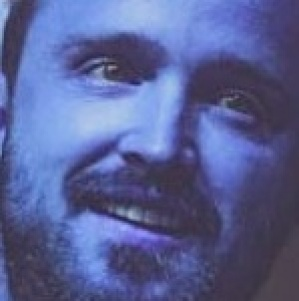

```
1
```

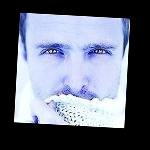

```
2it [00:00,  3.52it/s]
```

```
2
```

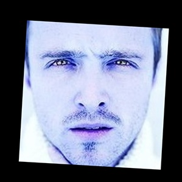

```
3it [00:01,  2.02it/s]
```

```
3
```

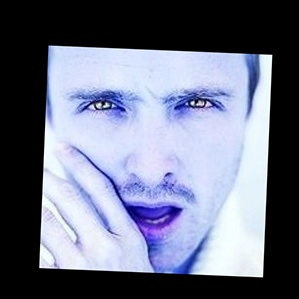

```
4it [00:02,  1.90it/s]
```

```
4
```

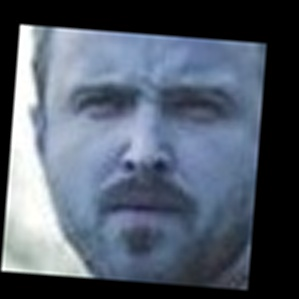

```
5it [00:02,  1.61it/s]
```

```
5
```

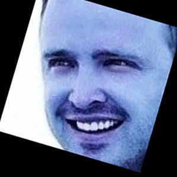

```
6it [00:03,  1.58it/s]
```

```
6
```

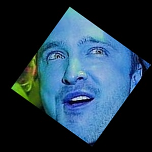

```
7it [00:04,  1.47it/s]
```

```
7
```

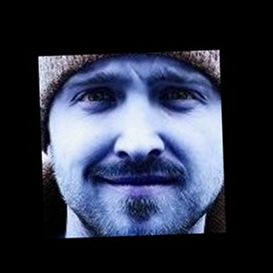

```
8it [00:04,  1.62it/s]
```

```
8
```

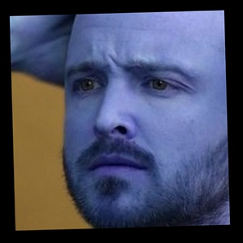

```
9it [00:05,  1.42it/s]
```

```
9
```

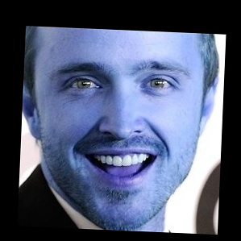

```
10770it [00:06, 1651.86it/s]
```

```python
for i, m in tqdm(enumerate(metadata)):
  if i < 10:
    print(i)
    cv2_imshow(load_image(m.image_path()))
```

```python
embeddings = np.zeros((metadata.shape[0], 2622))

for i, m in tqdm(enumerate(metadata)):
  try:
    img_loaded = load_image(m.image_path())
    # Normalising pixel values from [0-255] to [0-1]: scale RGB values to interval [0,1]
    img_loaded = (img_loaded / 255.).astype(np.float32)
    img_loaded = cv2.resize(img_loaded, dsize = (224,224))
    emb_vector = vgg_face_descriptor.predict(np.expand_dims(img_loaded, axis=0))[0]
  except:
    continue
  embeddings[i] = emb_vector
```

```
10770it [2:16:59,  1.31it/s]
```

### Function to calculate distance between given 2 pairs of images.

- Consider distance metric as "Squared L2 distance"
- Squared l2 distance between 2 points (x1, y1) and (x2, y2) = (x1-x2)^2 + (y1-y2)^2

```python
def distance(emb1, emb2):
    return np.sum(np.square(emb1 - emb2))
```

#### Plot images and get distance between the pairs given below

- 2, 3 and 2, 180
- 30, 31 and 30, 100
- 70, 72 and 70, 115

```python
def show_pair(idx1, idx2):
    plt.figure(figsize=(8,3))
    plt.suptitle(f'Distance = {distance(embeddings[idx1], embeddings[idx2]):.2f}')
    plt.subplot(121)
    plt.imshow(load_image(metadata[idx1].image_path()))
    plt.subplot(122)
    plt.imshow(load_image(metadata[idx2].image_path()));
```

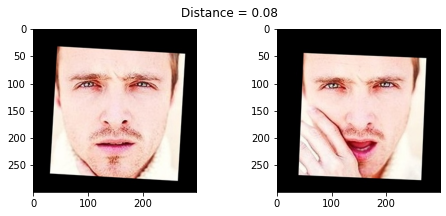

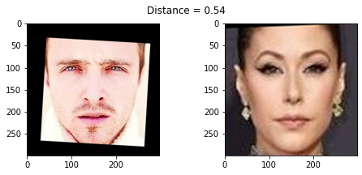

```python
show_pair(2, 3)
show_pair(2, 180)
```

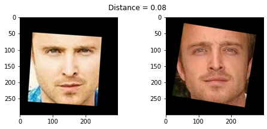

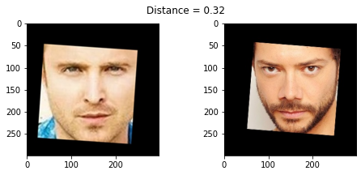

```python
show_pair (30,31)
show_pair (30,100)
```

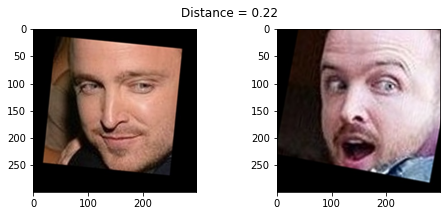

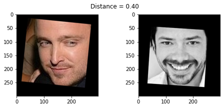

```python
show_pair (70,72)
show_pair (70,115)
```

```python
embeddings.shape
```

```
(10770, 2622)
```

### Create train and test sets

- Create X_train, X_test and y_train, y_test
- Use train_idx to seperate out training features and labels
- Use test_idx to seperate out testing features and labels

```python
train_idx = np.arange(metadata.shape[0]) % 9 != 0
#every 9th example goes in test data and rest go in train data
test_idx = np.arange(metadata.shape[0]) % 9 == 0

# one half as train examples of 10 identities
X_train = embeddings[train_idx]
# another half as test examples of 10 identities
X_test = embeddings[test_idx]

#### Add your code here ####

targets = np.array([m.name for m in metadata])
#train labels
y_train = targets[train_idx]
#test labels
y_test = targets[test_idx]
```

### Encode the Labels

- Encode the targets
- Use LabelEncoder

```python
targets = np.array([m.name for m in metadata])
encoder = LabelEncoder()
encoder.fit(targets)
y = encoder.transform(targets)
y_train_enc = y[train_idx]
y_test_enc = y[test_idx]
```

### Standardize the feature values

- Scale the features using StandardScaler

```python
scaler = StandardScaler()
scaler.fit(X_train)

X_train_std = scaler.transform(X_train)
X_test_std = scaler.transform(X_test)
```

### Reduce dimensions using PCA

- Reduce feature dimensions using Principal Component Analysis

```python
pca = PCA(n_components=128)

X_train_pca = pca.fit_transform(X_train_std)
X_test_pca = pca.transform(X_test_std)

print(X_train_pca.shape)
```

```
(9573, 128)
```

```python
explained_variance = pca.explained_variance_ratio_
print(explained_variance)
```

```
[0.13575494 0.05406738 0.03990371 0.03685078 0.03402273 0.03127777
 0.02590833 0.02332789 0.02102245 0.01944013 0.01819451 0.0170258
 0.01655608 0.01560168 0.01418262 0.01363994 0.01303526 0.01229511
 0.01155414 0.01134836 0.0109028  0.0105497  0.00961244 0.00934983
 0.00913501 0.00884051 0.00834691 0.00768297 0.00762954 0.00736093
 0.00699687 0.00663676 0.00632573 0.00622506 0.00571738 0.00535439
 0.00528947 0.00512591 0.0050768  0.00483017 0.00438503 0.00433925
 0.00395623 0.00393096 0.00369285 0.00356469 0.00341063 0.00333917
 0.00328845 0.00319854 0.00313083 0.00308178 0.00290197 0.00281966
 0.00278952 0.00273338 0.00267884 0.00260945 0.00253119 0.0024858
 0.00237435 0.00231919 0.00225453 0.00217408 0.00210864 0.00205224
 0.00200082 0.00194378 0.00187251 0.0018475  0.00182411 0.00179282
 0.00173943 0.00173333 0.00169965 0.00165704 0.00164181 0.00161525
 0.00157211 0.00155014 0.00152627 0.00149243 0.00146771 0.00143595
 0.00140385 0.00137735 0.00136092 0.00133985 0.00131558 0.00128797
 0.00126694 0.00125368 0.00123276 0.00122755 0.00120332 0.001196
 0.00118999 0.00116653 0.00115833 0.00111499 0.0011014  0.00108334
 0.00107767 0.00106412 0.00106073 0.00103712 0.00103046 0.0010177
 0.00099068 0.00098648 0.00096093 0.00094928 0.00093858 0.00092765
 0.00091985 0.00091128 0.00090173 0.00088541 0.00086987 0.00086529
 0.00085352 0.00085126 0.0008411  0.00082857 0.00080489 0.00079459
 0.00078988 0.00077469]
```

### Build a Classifier

- Use SVM Classifier to predict the person in the given image
- Fit the classifier and print the score

```python
# defining parameter range
param_grid = {'C': [0.1, 1, 10,20,30 ,50, 100],
              'gamma': [1, 0.1, 0.01],
              'kernel': ['linear','rbf','poly']}

grid = GridSearchCV(SVC(), param_grid, verbose = 3)

# fitting the model for grid search
grid.fit(X_train_pca, y_train_enc)

# print best parameter after tuning
print(grid.best_params_)

# print how our model looks after hyper-parameter tuning
print(grid.best_estimator_)
```

```
Fitting 5 folds for each of 63 candidates, totalling 315 fits
[CV] C=0.1, gamma=1, kernel=linear ...................................
```

```
[Parallel(n_jobs=1)]: Using backend SequentialBackend with 1 concurrent workers.
```

```
[CV] ....... C=0.1, gamma=1, kernel=linear, score=0.959, total=   4.6s
[CV] C=0.1, gamma=1, kernel=linear ...................................
```

```
[Parallel(n_jobs=1)]: Done   1 out of   1 | elapsed:    4.6s remaining:    0.0s
```

```
[CV] ....... C=0.1, gamma=1, kernel=linear, score=0.952, total=   4.6s
[CV] C=0.1, gamma=1, kernel=linear ...................................
```

```
[Parallel(n_jobs=1)]: Done   2 out of   2 | elapsed:    9.2s remaining:    0.0s
```

[output not shown]

[output cut: 570 more lines]

```
[CV] ....... C=100, gamma=0.01, kernel=rbf, score=0.100, total=  28.0s
[CV] C=100, gamma=0.01, kernel=rbf ...................................
[CV] ....... C=100, gamma=0.01, kernel=rbf, score=0.103, total=  28.0s
[CV] C=100, gamma=0.01, kernel=rbf ...................................
[CV] ....... C=100, gamma=0.01, kernel=rbf, score=0.099, total=  28.2s
[CV] C=100, gamma=0.01, kernel=poly ..................................
[CV] ...... C=100, gamma=0.01, kernel=poly, score=0.944, total=   7.5s
[CV] C=100, gamma=0.01, kernel=poly ..................................
[CV] ...... C=100, gamma=0.01, kernel=poly, score=0.949, total=   7.5s
[CV] C=100, gamma=0.01, kernel=poly ..................................
[CV] ...... C=100, gamma=0.01, kernel=poly, score=0.942, total=   7.5s
[CV] C=100, gamma=0.01, kernel=poly ..................................
[CV] ...... C=100, gamma=0.01, kernel=poly, score=0.951, total=   7.6s
[CV] C=100, gamma=0.01, kernel=poly ..................................
[CV] ...... C=100, gamma=0.01, kernel=poly, score=0.949, total=   7.6s
```

```
[Parallel(n_jobs=1)]: Done 315 out of 315 | elapsed: 70.2min finished
```

```
{'C': 0.1, 'gamma': 1, 'kernel': 'linear'}
SVC(C=0.1, break_ties=False, cache_size=200, class_weight=None, coef0=0.0,
    decision_function_shape='ovr', degree=3, gamma=1, kernel='linear',
    max_iter=-1, probability=False, random_state=None, shrinking=True,
    tol=0.001, verbose=False)
```

```python
svc = SVC( C=0.1, gamma= 1, kernel='linear')
svc.fit(X_train_pca, y_train_enc)
```

```
SVC(C=0.1, break_ties=False, cache_size=200, class_weight=None, coef0=0.0,
    decision_function_shape='ovr', degree=3, gamma=1, kernel='linear',
    max_iter=-1, probability=False, random_state=None, shrinking=True,
    tol=0.001, verbose=False)
```

```python
# predict
y_pred_train = svc.predict(X_train_pca)
y_pred_test = svc.predict(X_test_pca)
# score
score_train = accuracy_score(y_train_enc, y_pred_train)
score_test = accuracy_score(y_test_enc, y_pred_test)
# summarize
print('Accuracy: train=%.3f, test=%.3f' % (score_train*100, score_test*100))
```

```
Accuracy: train=99.979, test=95.322
```

### Test results

- Take 10th image from test set and plot the image
- Report to which person(folder name in dataset) the image belongs to

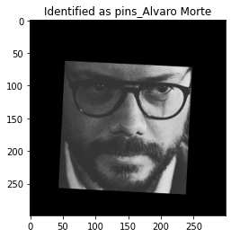

```python
import warnings
# Suppress LabelEncoder warning
warnings.filterwarnings('ignore')

example_idx = 10

example_image = load_image(metadata[test_idx][example_idx].image_path())
#example_prediction = svc.predict([embeddings[test_idx][example_idx]])
example_prediction = svc.predict(X_test_pca[example_idx].reshape(1,-1))
example_identity = encoder.inverse_transform(example_prediction)[0]

plt.imshow(example_image)
plt.title(f'Identified as {example_identity}');
```